# Women NCAA EDA

Akeem Ajede

3/24/2020

## Introduction

The dataset of interest is the female NCAA dataset. The reason for exploring this particular dataset is that less attention is paid to the female team in sports in general, so this is a sincere effort at changing the narrative.

Step 1: Setting up the generic theme for this data exploration.

```r
library(tidyverse)
library(scales)
library(gridExtra)
library(knitr)
#install.packages("ggExtra")
library(ggExtra)
```

```r
library(ggplot2)

# set up plotting theme
theme_akeem <- function(legend_pos="top", base_size=11, font=NA){

  # come up with some default text details
  txt <- element_text(size = base_size+3, colour = "black", face = "plain")
  bold_txt <- element_text(size = base_size+3, colour = "black", face = "bold")

  # use the theme_minimal() theme as a baseline
  theme_minimal(base_size = base_size, base_family = font)+
    theme(text = txt,
          # axis title and text
          axis.title.x = element_text(size = 15, hjust = 1),
          axis.title.y = element_text(size = 15),
          # gridlines on plot
          panel.grid.major = element_line(linetype = 2),
          panel.grid.minor = element_line(linetype = 2),
          # title and subtitle text
          plot.title = element_text(size = 18, colour = "grey25", face = "bold"),
          plot.subtitle = element_text(size = 16, colour = "grey44"),

          ###### clean up!
          legend.key = element_blank(),
          # the strip.* arguments are for faceted plots
          strip.background = element_blank(),
          strip.text = element_text(face = "bold", size = 13, colour = "grey35")) +

    #----- AXIS -----#
    theme(
      #### remove Tick marks
      axis.ticks=element_blank(),

      ### legend depends on argument in function and no title
      legend.position = legend_pos,
      legend.title = element_blank(),
      legend.background = element_rect(fill = NULL, size = 0.5,linetype = 2)


    )
}


plot_cols <- c("#498972", "#3E8193", "#BC6E2E", "#A09D3C", "#E06E77", "#7589BC", "#A57BAF", "#4D4D4D")
```

## Offloading the “Women NCAA” datasets.

Step 2: Offloaded the dataset and took a quick “glimpse” at one of the imported data.

```r
#Load the data

reg_season_stats <- as.tibble(read.csv("march-madness-analytics-2020/2020DataFiles/2020-Womens-Data/WDataFiles_Stage1/WRegularSeasonDetailedResults.csv",
                                       stringsAsFactors = F))
tourney_stats <- as.tibble(read.csv("march-madness-analytics-2020/2020DataFiles/2020-Womens-Data/WDataFiles_Stage1/WNCAATourneyDetailedResults.csv",
                          stringsAsFactors = F))
teams <- as.tibble(read.csv("march-madness-analytics-2020/2020DataFiles/2020-Womens-Data/WDataFiles_Stage1/WTeams.csv", stringsAsFactors = F))

tourney_stats_compact <- read.csv("march-madness-analytics-2020/2020DataFiles/2020-Womens-Data/WDataFiles_Stage1/WNCAATourneyCompactResults.csv", stringsAsFactors = F)
tourney_seeds <- as.tibble(read.csv("march-madness-analytics-2020/2020DataFiles/2020-Womens-Data/WDataFiles_Stage1/WNCAATourneySeeds.csv",
                          stringsAsFactors = F)) %>%
  drop_na(Seed)
team_conferences <- as.tibble(read.csv("march-madness-analytics-2020/2020DataFiles/2020-Womens-Data/WDataFiles_Stage1/WTeamConferences.csv",
                                       stringsAsFactors = F))
conferences <- as.tibble(read.csv("march-madness-analytics-2020/2020DataFiles/2020-Womens-Data/WDataFiles_Stage1/Conferences.csv",
                                  stringsAsFactors = F))
players <- read.csv("march-madness-analytics-2020/2020DataFiles/2020-Womens-Data/WPlayers.csv",
                     stringsAsFactors = F, na.strings = c("", "NA")) %>%
  filter(!is.na(LastName)) %>%
  as.tibble()


glimpse(players)
```

```
## Observations: 11,605
## Variables: 4
## $ PlayerID  <int> 1, 2, 3, 4, 5, 6, 7, 8, 9, 10, 11, 12, 13, 14, 15, 1...
## $ LastName  <chr> "Adams", "Allen", "Avery", "Cooper", "Dimba", "Dimba...
## $ FirstName <chr> "Alyssa", "Sierra", "Ellyn", "Jenna", "Lizzy", "Suzz...
## $ TeamID    <int> 3101, 3101, 3101, 3101, 3101, 3101, 3101, 3101, 3101...
```

## Play_by_play analysis (Step 3)

This section involves a logical data wrangling. Specifically, the algorithm was written to loop through the women dataset and set the tune on how the data will be explored at the granular level.

```r
play_by_play <- data.frame()

# loop through each seasons PlayByPlay folders and read in in the play by play files
for(each in list.files("march-madness-analytics-2020/2020DataFiles/2020-Womens-Data/")[str_detect(list.files("march-madness-analytics-2020/2020DataFiles/2020-Womens-Data/"), "WEvents")]) {
  df <- read_csv(paste0("march-madness-analytics-2020/2020DataFiles/2020-Womens-Data/", each))


  # Grouped shooting variables ----------------------------------------------
  # there are some shooting variables that can probably be condensed - tip ins and dunks
  paint_attempts_made <- c("made2_dunk", "made2_lay", "made2_tip")
  paint_attempts_missed <- c("miss2_dunk", "miss2_lay", "miss2_tip")
  paint_attempts <- c(paint_attempts_made, paint_attempts_missed)

  # create variables for field goals made (FGM), and also field goals attempted (FGA)(which includes the sum of FGs made and FGs missed)
  FGM <- c("made2_dunk", "made2_jump", "made2_lay",  "made2_tip",  "made3_jump")
  FGA <- c(FGM, "miss2_dunk", "miss2_jump" ,"miss2_lay",  "miss2_tip",  "miss3_jump")
  # variable for three-pointers
  ThreePointer <- c("made3_jump", "miss3_jump")
  #  Two point jumper
  TwoPointJump <- c("miss2_jump", "made2_jump")
  # Free Throws
  FT <- c("miss1_free", "made1_free")
  # all shots
  AllShots <- c(FGA, FT)


  # Feature Engineering -----------------------------------------------------
  # paste the two even variables together for FGs as this is the format for last years comp data
  df <- df %>%
    mutate_if(is.factor, as.character) %>%
    mutate(EventType = ifelse(str_detect(EventType, "miss") | str_detect(EventType, "made") | str_detect(EventType, "reb"), paste0(EventType, "_", EventSubType), EventType))

  # change the unknown for 3s to "jump" and for FTs "free"
  df <- df %>%
    mutate(EventType = ifelse(str_detect(EventType, "3"), str_replace(EventType, "_unk", "_jump"), EventType),
           EventType = ifelse(str_detect(EventType, "1"), str_replace(EventType, "_unk", "_free"), EventType))


  df <- df %>%
    # create a variable in the df for whether the attempts was made or missed
    mutate(shot_outcome = ifelse(grepl("made", EventType), "Made", ifelse(grepl("miss", EventType), "Missed", NA))) %>%
    # identify if the action was a field goal, then group it into the attempt types set earlier
    mutate(FGVariable = ifelse(EventType %in% FGA, "Yes", "No"),
           AttemptType = ifelse(EventType %in% paint_attempts, "PaintPoints",
                                ifelse(EventType %in% ThreePointer, "ThreePointJumper",
                                       ifelse(EventType %in% TwoPointJump, "TwoPointJumper",
                                              ifelse(EventType %in% FT, "FreeThrow", "NoAttempt")))))


  # Rework DF so only shots are included and whatever lead to the shot --------
  df <- df %>%
    mutate(GameID = paste(Season, DayNum, WTeamID, LTeamID, sep = "_")) %>%
    group_by(GameID, ElapsedSeconds) %>%
    mutate(EventType2 = lead(EventType),
           EventPlayerID2 = lead(EventPlayerID)) %>% ungroup()


  df <- df %>%
    mutate(FGVariableAny = ifelse(EventType %in% FGA | EventType2 %in% FGA, "Yes", "No")) %>%
    filter(FGVariableAny == "Yes")


  # create a variable for if the shot was made, but then the second event was also a made shot
  df <- df %>%
    mutate(Alert = ifelse(EventType %in% FGM & EventType2 %in% FGM, "Alert", "OK")) %>%
    # only keep "OK" observations
    filter(Alert == "OK")
  # replace NAs with something
  df$EventType2[is.na(df$EventType2)] <- "no_second_event"


  # create a variable for if there was an assist on the FGM:
  df <- df %>%
    mutate(AssistedFGM = ifelse(EventType %in% FGM & EventType2 == "assist", "Assisted",
                                ifelse(EventType %in% FGM & EventType2 != "assist", "Solo",
                                       ifelse(EventType %in% FGM & EventType2 == "no_second_event", "Solo", "None"))))

  # # because the FGA could be either in `EventType` (more likely) or `EventType2` (less likely), need
  # # one variable to indicate the shot type
  # df <- df %>% \
  #   mutate(fg_type = ifelse(EventType %in% FGA, EventType, ifelse(EventType2 %in% FGA, EventType2, "Unknown")))

  # create final output
  df <- df %>% ungroup()
  play_by_play <- bind_rows(play_by_play, df)

  rm(df);gc() #remove garbage content
}
#saveRDS(play_by_play, "play_by_play15_19.rds")
# play_by_play <- readRDS("play_by_play2015_19.rds")
```

## Scoring patterns of the play-by-play analysis over the years (step 4)

```r
play_by_play %>%
  filter(Season == 2019) %>%
  as.tibble()    #2019 data
```

```
## # A tibble: 618,398 x 26
##    EventID Season DayNum WTeamID LTeamID WFinalScore LFinalScore
##      <dbl>  <dbl>  <dbl>   <dbl>   <dbl>       <dbl>       <dbl>
##  1  1.01e7   2019      1    3113    3230          81          43
##  2  1.01e7   2019      1    3113    3230          81          43
##  3  1.01e7   2019      1    3113    3230          81          43
##  4  1.01e7   2019      1    3113    3230          81          43
##  5  1.01e7   2019      1    3113    3230          81          43
##  6  1.01e7   2019      1    3113    3230          81          43
##  7  1.01e7   2019      1    3113    3230          81          43
##  8  1.01e7   2019      1    3113    3230          81          43
##  9  1.01e7   2019      1    3113    3230          81          43
## 10  1.01e7   2019      1    3113    3230          81          43
## # ... with 618,388 more rows, and 19 more variables: WCurrentScore <dbl>,
## #   LCurrentScore <dbl>, ElapsedSeconds <dbl>, EventTeamID <dbl>,
## #   EventPlayerID <dbl>, EventType <chr>, EventSubType <chr>, X <dbl>,
## #   Y <dbl>, Area <dbl>, shot_outcome <chr>, FGVariable <chr>,
## #   AttemptType <chr>, GameID <chr>, EventType2 <chr>,
## #   EventPlayerID2 <dbl>, FGVariableAny <chr>, Alert <chr>,
## #   AssistedFGM <chr>
```

```r
library(DT)
#PlaybyPlay seasons range from 2015 to 2019
summary(play_by_play$Season)
```

```
##    Min. 1st Qu.  Median    Mean 3rd Qu.    Max.
##    2015    2016    2017    2017    2018    2019
```

```r
#Sum of field goals made and missed from 2015 to 2019
play_by_play %>%
  group_by(shot_outcome) %>%
  summarise(number_of_shots = n()) %>%
  arrange(desc(number_of_shots))
```

```
## # A tibble: 3 x 2
##   shot_outcome number_of_shots
##   <chr>                  <int>
## 1 Missed               1853421
## 2 Made                 1228636
## 3 <NA>                   53718
```

```r
# Sum of field goals made (FGM) in 2019
filter(play_by_play, play_by_play$Season == 2019) %>%
  group_by(shot_outcome) %>%
  summarise(number_of_shots = n()) %>%
  arrange(desc(number_of_shots))
```

```
## # A tibble: 3 x 2
##   shot_outcome number_of_shots
##   <chr>                  <int>
## 1 Missed                364129
## 2 Made                  238693
## 3 <NA>                   15576
```

```r
## Morey Ball in the NCAA

play_by_play %>%
  group_by(AttemptType) %>%
  summarise(number_of_shots = n()) %>%
  arrange(desc(number_of_shots)) %>%
  DT::datatable()         # Shots in descending order
```

|  | AttemptType | number_of_shots |
| --- | --- | --- |
| 1 | TwoPointJumper | 1068325 |
| 2 | PaintPoints | 1056372 |
| 3 | ThreePointJumper | 954881 |
| 4 | NoAttempt | 54104 |
| 5 | FreeThrow | 2093 |

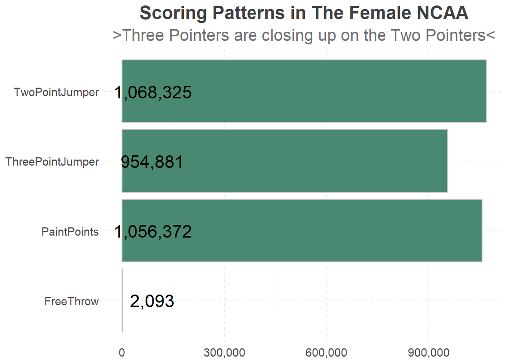

```r
# Scoring patterns
play_by_play %>%
  group_by(AttemptType) %>%
  summarise(number_of_shots = n()) %>%
  filter(AttemptType != "NoAttempt") %>%
  ggplot(aes(x= AttemptType, y= number_of_shots)) +
  geom_col(fill = plot_cols[1], colour = "grey") +
  geom_text(aes(label = comma(number_of_shots)), y=90000, colour = "black", size = 6) +
  scale_y_continuous(labels = c("0", "300,000", "600,000", "900,000", "1,200,000\nattempts")) +
  coord_flip() +
  ggtitle("Scoring Patterns in The Female NCAA", subtitle = ">Three Pointers are closing up on the Two Pointers<") +
  theme_akeem() +
  theme(axis.title.x = element_blank(), axis.title.y = element_blank(), plot.title = element_text(hjust = 0.5), plot.subtitle = element_text(hjust = 0.5))
```

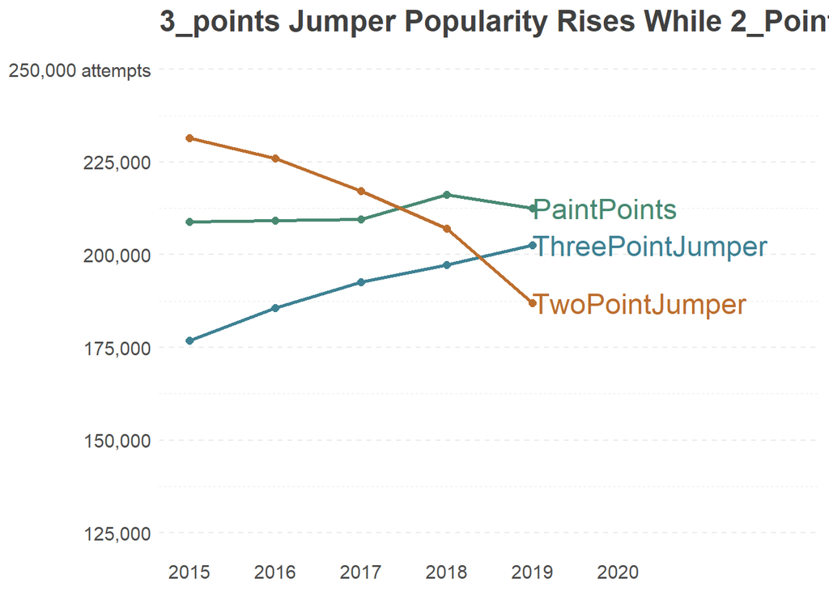

```r
## Scoring pattern trend over the years
p_tab <- play_by_play %>%
  filter(AttemptType != "FreeThrow") %>%
  group_by(AttemptType, Season) %>%
  summarise(n_shots = n()) %>%
  filter(AttemptType != "NoAttempt") %>%
  filter(Season == 2019) %>% ungroup()


play_by_play %>%
  filter(AttemptType != "FreeThrow") %>%
  group_by(AttemptType, Season) %>%
  summarise(n_shots = n()) %>%
  filter(AttemptType != "NoAttempt") %>%
  ggplot(aes(x= Season, y= n_shots, colour = AttemptType, group = AttemptType)) +
  geom_line(size = 1) +
  geom_point(size = 2) +
  geom_text(data = p_tab, aes(label = AttemptType), hjust= 0, size=6) +
  scale_color_manual(values = plot_cols) +
  scale_x_continuous(labels = c(2015:2020), breaks = c(2015:2020), limits = c(2015, 2022)) +
  scale_y_continuous(labels = c("125,000", "150,000", "175,000", "200,000", "225,000", "250,000 attempts"), breaks = c(seq(from=125000, to= 250000, by= 25000)), limits = c(125000, 250000)) +
  ggtitle("3_points Jumper Popularity Rises While 2_Points Jumper Diminishes") +
  theme_akeem(legend_pos = "none") +
  theme(panel.grid.major.x = element_blank(), panel.grid.minor.x = element_blank(), axis.title.x = element_blank(), axis.title.y = element_blank())
```